# Analysis of the Palmer Penguins Dataset

Moaz Mohammed El-Esawey

10/25/2021

## Loading the dataset and packages used

we load the *palmerpenguins* package as it contains the data for out analysis. and tidyverse which contains some packages like *dplyr*, *ggplot* and more that is useful for analysis

```r
library('palmerpenguins')
library('tidyverse')
```

```r
## clean the data and remove all the NA values.
penguins <- penguins %>%
  drop_na()

dim(penguins)
```

```
## [1] 333   8
```

```r
head(penguins)
```

```
## # A tibble: 6 × 8
##   species island bill_length_mm bill_depth_mm flipper_length_… body_mass_g sex
##   <fct>   <fct>           <dbl>         <dbl>            <int>       <int> <fct>
## 1 Adelie  Torge…           39.1          18.7              181        3750 male
## 2 Adelie  Torge…           39.5          17.4              186        3800 fema…
## 3 Adelie  Torge…           40.3          18                195        3250 fema…
## 4 Adelie  Torge…           36.7          19.3              193        3450 fema…
## 5 Adelie  Torge…           39.3          20.6              190        3650 male
## 6 Adelie  Torge…           38.9          17.8              181        3625 fema…
## # … with 1 more variable: year <int>
```

```r
unique(penguins$species)
```

```
## [1] Adelie    Gentoo    Chinstrap
## Levels: Adelie Chinstrap Gentoo
```

```r
unique(penguins$island)
```

```
## [1] Torgersen Biscoe    Dream
## Levels: Biscoe Dream Torgersen
```

the data have recorded is **bill_length_mm**, **bill_depth_mm**, **flipper_length_mm** and **body_mass_g** for each penguin.

## Summary statictics for the dataset

```r
penguins %>%
  group_by(species) %>%
  drop_na() %>%
  summarise(mean_fl=mean(flipper_length_mm), mean_bm=mean(body_mass_g)) %>%
  arrange(mean_fl)
```

```
## # A tibble: 3 × 3
##   species   mean_fl mean_bm
##   <fct>       <dbl>   <dbl>
## 1 Adelie       190.   3706.
## 2 Chinstrap    196.   3733.
## 3 Gentoo       217.   5092.
```

as we show above the **Gentoo** specie is the biggest flipper_length_mm and body_mass_g we means that it’s the largest penguin in all species.

## Visualizations

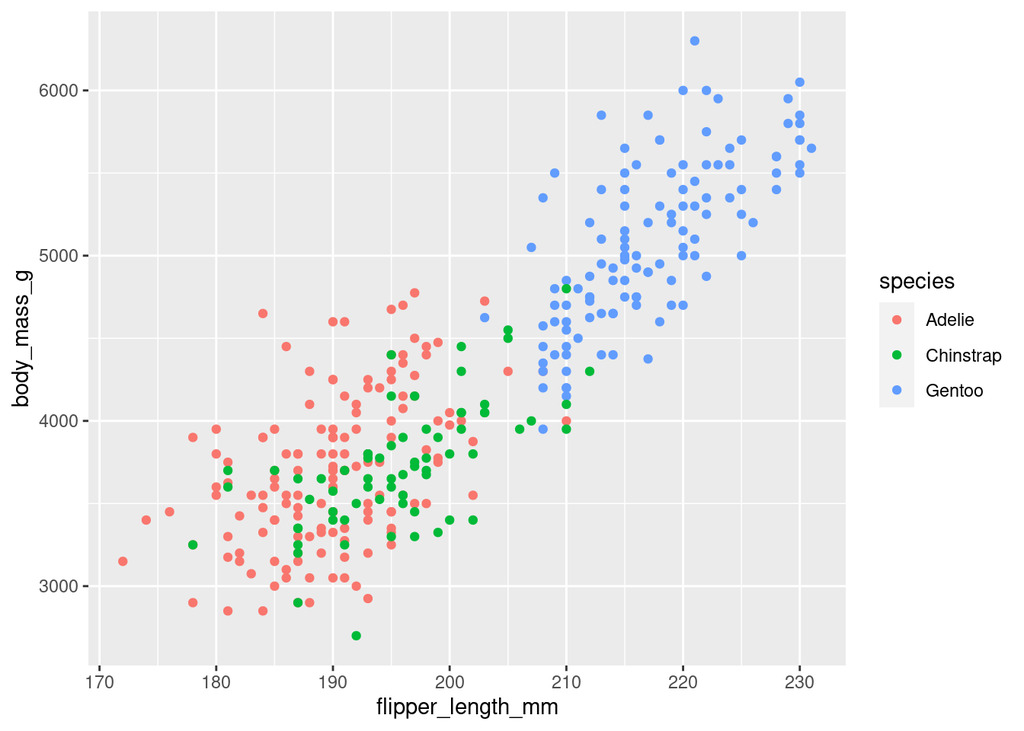

```r
ggplot(data=penguins, aes(x=flipper_length_mm, y=body_mass_g))+
  geom_point(aes(color=species))
```

As we see that the **Gentoo** specie is the biggest and also found to be alone and with its own cluster of points away from the other two species.

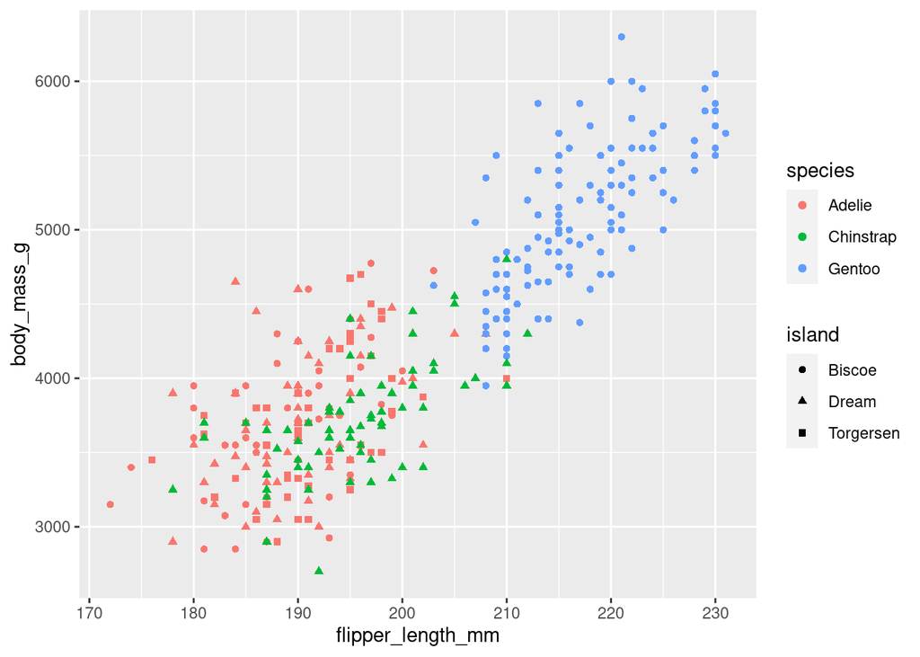

```r
ggplot(data=penguins, aes(x=flipper_length_mm, y=body_mass_g))+
  geom_point(aes(color=species, shape=island))
```

Also I found that the **Gentoo** specie found to live alone from the other in the **Biscoe** island.

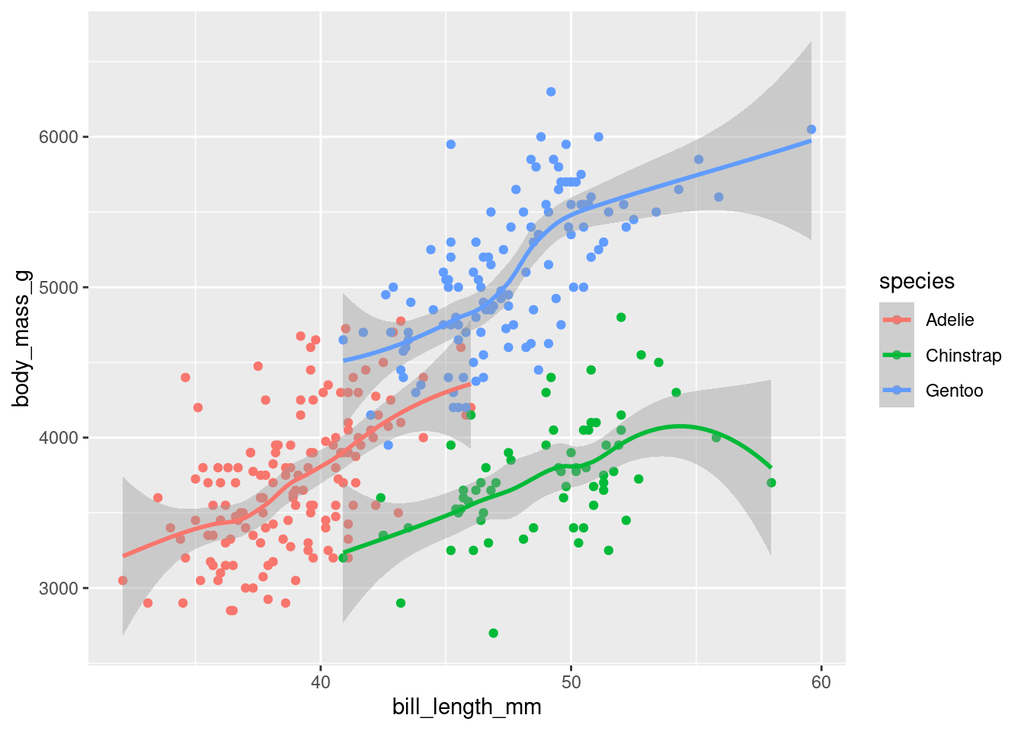

```r
ggplot(data=penguins, aes(x=bill_length_mm, y=body_mass_g))+
  geom_point(aes(color=species))+
  geom_smooth(aes(color=species))
```

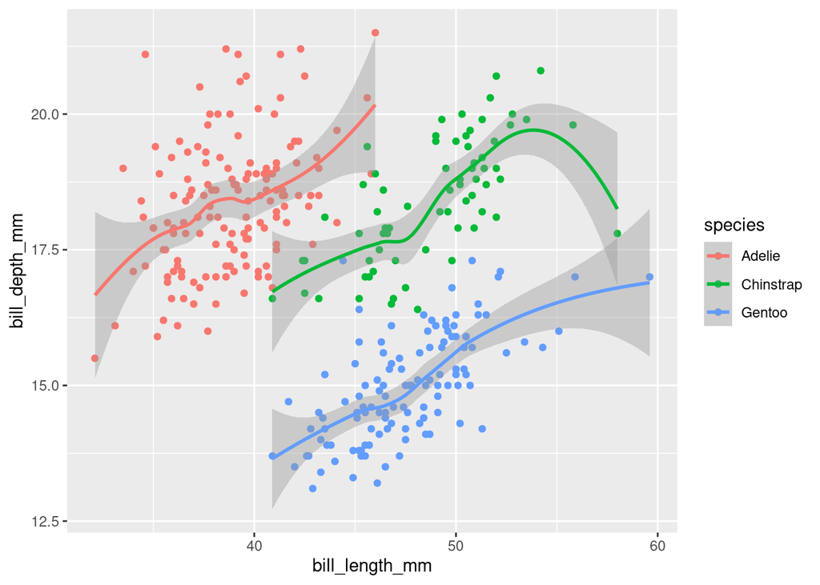

```r
ggplot(data=penguins, aes(x=bill_length_mm, y=bill_depth_mm))+
  geom_point(aes(color=species))+
  geom_smooth(aes(color=species))
```

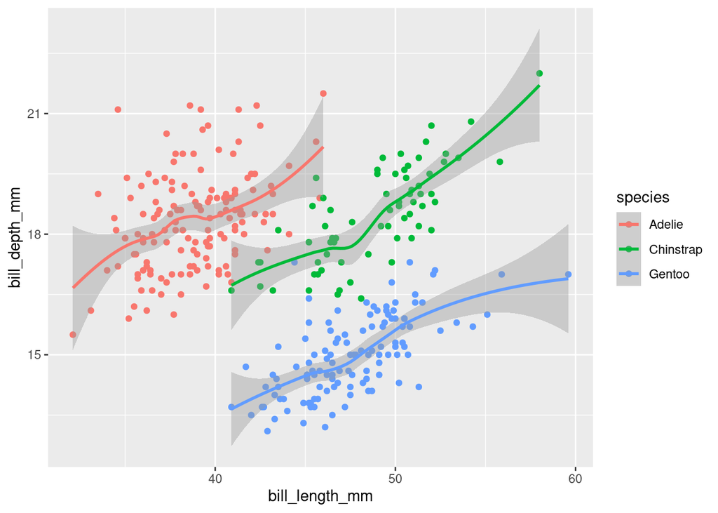

```r
penguins_copy <- data.frame(penguins)

penguins_copy <- penguins_copy  %>%
  mutate(bill_depth_mm=replace(bill_depth_mm, bill_length_mm==58.0, 22))
#
# penguins_copy %>%
#   filter(species=='Chinstrap') %>%
#   arrange(-bill_length_mm)

ggplot(data=penguins_copy, aes(x=bill_length_mm, y=bill_depth_mm))+
  geom_point(aes(color=species))+
  geom_smooth(aes(color=species))
```

```r
penguins %>%
  filter(species=='Chinstrap') %>%
  arrange(-bill_length_mm)
```

```
## # A tibble: 68 × 8
##    species   island bill_length_mm bill_depth_mm flipper_length_mm body_mass_g
##    <fct>     <fct>           <dbl>         <dbl>             <int>       <int>
##  1 Chinstrap Dream            58            17.8               181        3700
##  2 Chinstrap Dream            55.8          19.8               207        4000
##  3 Chinstrap Dream            54.2          20.8               201        4300
##  4 Chinstrap Dream            53.5          19.9               205        4500
##  5 Chinstrap Dream            52.8          20                 205        4550
##  6 Chinstrap Dream            52.7          19.8               197        3725
##  7 Chinstrap Dream            52.2          18.8               197        3450
##  8 Chinstrap Dream            52            18.1               201        4050
##  9 Chinstrap Dream            52            19                 197        4150
## 10 Chinstrap Dream            52            20.7               210        4800
## # … with 58 more rows, and 2 more variables: sex <fct>, year <int>
```

in the above output the **Chinstrap** specie with the **bill_length_mm=58.0** seems to be an outlier for it or just might be classified wrongly as it should be a **Gentoo** specie. which can be shown in the smooth_line drawn in the above figure. or it might be a conversion as the bill_length_mm increased the penguin started to converts from **Chinstrap** to **Gentoo** .

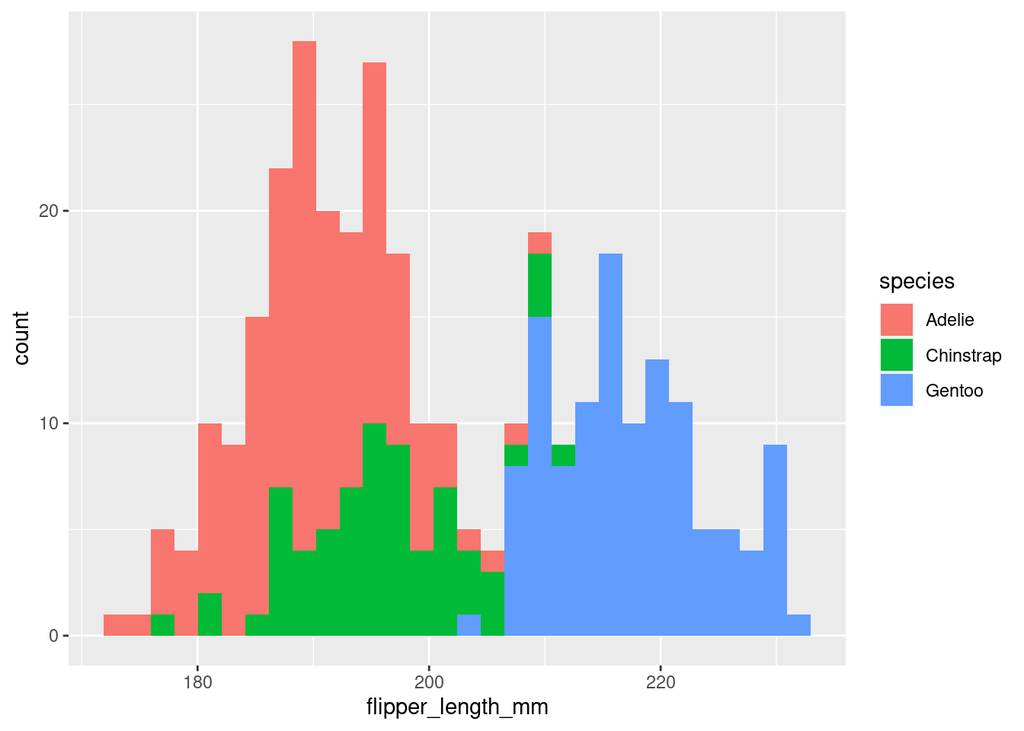

```r
ggplot(data=penguins) +
  geom_histogram(mapping=aes(x=flipper_length_mm, fill=species), bins = 30)
```

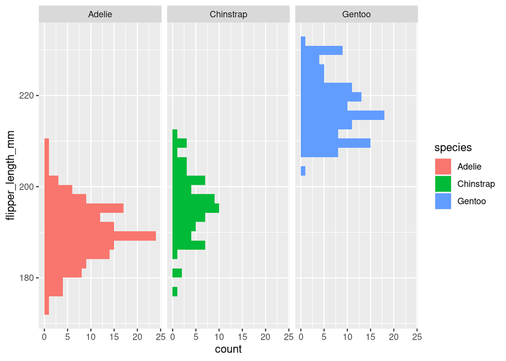

```r
ggplot(data=penguins) +
  geom_histogram(mapping=aes(y=flipper_length_mm, fill=species), bins = 30)+
  facet_wrap(~species)
```

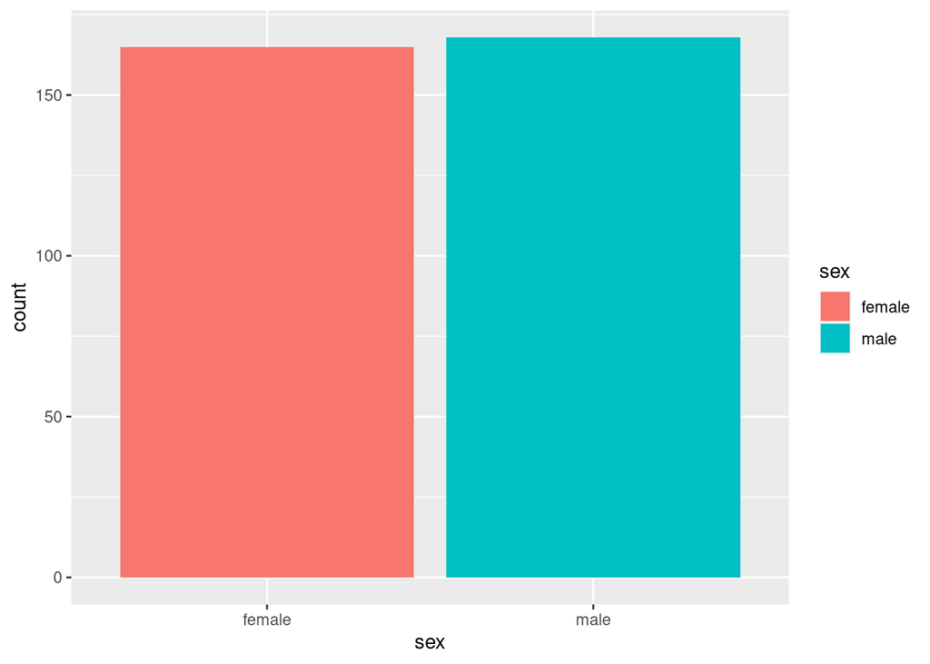

```r
ggplot(penguins)+
  geom_bar(aes(sex, fill=sex))
```

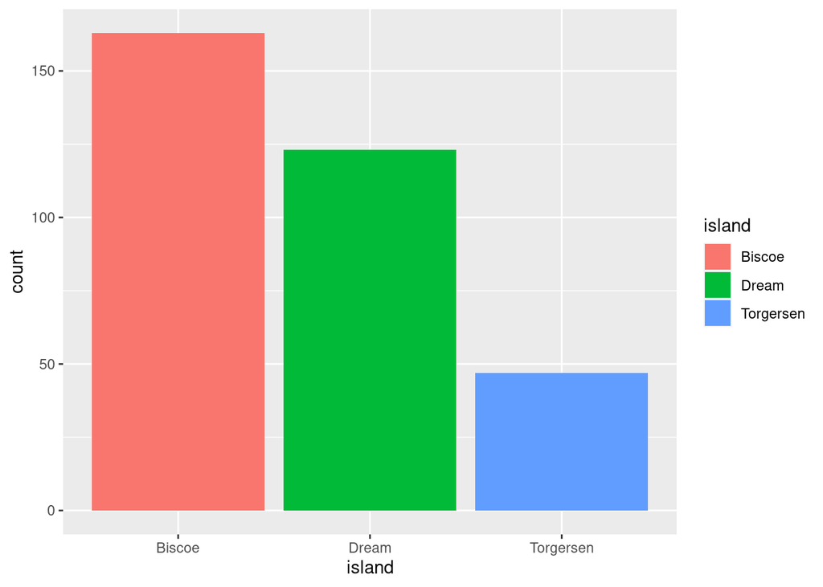

```r
ggplot(penguins)+
  geom_bar(aes(island, fill=island))
```

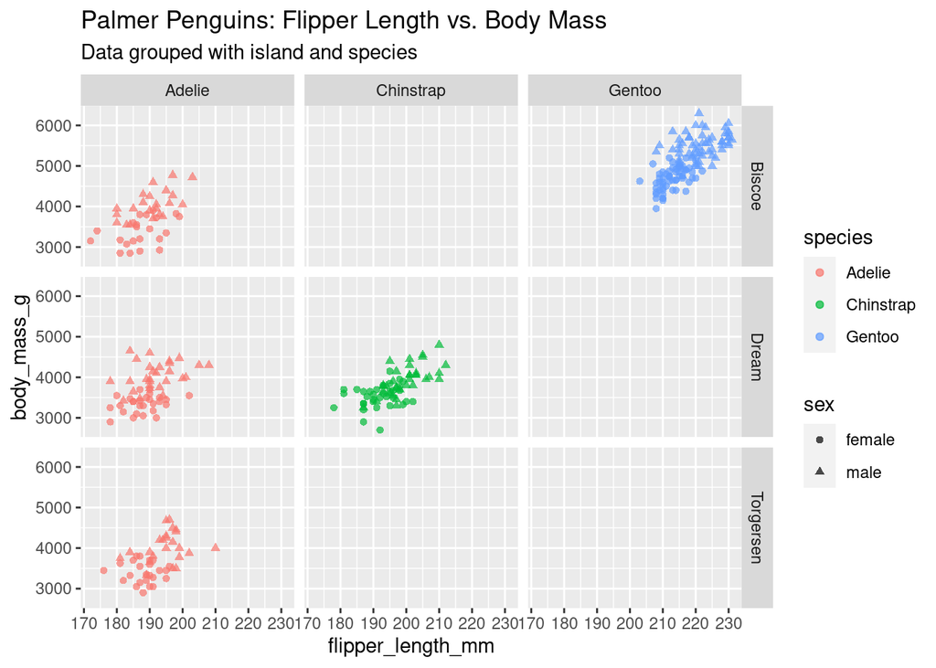

```r
ggplot(penguins)+
  geom_point(aes(x=flipper_length_mm, y=body_mass_g,
                 color=species, shape=sex), alpha=.7)+
  facet_grid(island~species)+
  labs(title="Palmer Penguins: Flipper Length vs. Body Mass",
       subtitle='Data grouped with island and species')
```

As shown in the above plot. We found that **Adelie** specie found in all the three island that why it has more records. in the dataset and the **Chinstrap** specie only shown in the **Dream** island and the **Gentoo** specie shown only in the **Biscoe** island.